# Section 2.1 Sampling Distributions

Last updated Monday, September 28, 2026 @ 12:11 PM

## Before We Begin…

These slides are meant to accompany the text [*Introduction to Statistical Investigations, 2nd Edition*](http://www.isi-stats.com/isi/index2nd.html) — Section 2.1 Sampling from a Finite Population: Proportions.

*This content does not replace reading the relevant textbook section.* It is for class presentation, review, and reference.

## Recall: Spiral Approach & Four Pillars

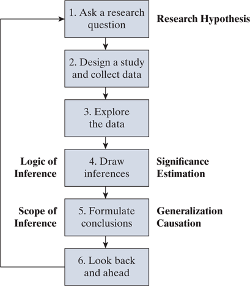

- We addressed strength of evidence (significance) in Chapter 1. ✔ *Good job!*
- **We will discuss *breadth* of results (generalization) in Chapter 2.**
- We will discover the *size* of an effect (estimation) in Chapter 3.
- Chapter 4 will introduce the concept of causation, the last of the four pillars.

## *So* … What’s Different from Chapter 1?

In Chapter 1, we generated many hypothetical samples from a specified probability model to model our null hypothesis \(H_0\). In those cases, \(\pi\) is a *hypothetical value* we assumed.

In a test of significance, we use the hypothetical \(\pi\) to try to make an inference about an *actual population* \(\pi\).

Now we are taking samples from an actual population. Why? So we can explore what kinds of samples we might get. In this case, \(\pi\) is an actual population value we theoretically specify.

We will use the similarity between the two ideas in Section 3.1 to estimate a population \(\pi\) using a *confidence interval*. We will build on the idea of sampling distributions in Section 3.2.

## Learning Goals for Chapter 2

We will do Sections 2.1 and 2.2 in our course. They introduce the concepts of random samples, sampling distributions of \(\hat{p}\) and \(\bar{x}\), and the **Central Limit Theorem**.

- Describe how to select a random sample. [Section 2.1]
- Understand and predict sampling distributions for a sample proportion and a sample mean. [Sections 2.1 and 2.2]

We will *not* cover Sections 2.3 and 2.4 (theory / bootstrapping).

This material builds on the Preliminaries and Chapter 1. You will need to remember and use vocabulary and concepts from those Chapters to understand new material in this section. Section 2.1 provides a foundation for the upcoming Section 3.2.

## Learning Goals for Section 2.1

- Identify parameters (long-run proportion) and statistics (sample proportion) in a statistical study.
- Identify which statistics (proportions) and graphs (bar graph) are appropriate for categorical variables, construct graphs and calculate statistics with use of technology, and interpret appropriately.
- Identify the (finite) population and the sample in a statistical study.
- Identify whether a sampling method is likely to be biased and explain the potential impact.
- Describe how to select a random sample and recognize that one advantage of a random sample is that it is likely to be representative of the population regardless of sample size.

## *More* Learning Goals for Section 2.1

- Fill in a data table where rows are the observational units and columns are the variables.
- Predict the mean, standard deviation, and shape of the sampling distribution of a sample proportion from a random sample of size \(n\), where the population proportion is known.
- Apply simulation-based inference methods for a population proportion to research studies involving random samples from finite populations.
- Identify whether a study may be impacted by non-sampling concerns and explain the potential impact.

*This chapter is a little more theoretical/conceptual. We will need it going forward to understand some of the upcoming methods. One important idea is generalizing beyond the sample (**breadth**).*

## Section 2.1 New Vocabulary

- bias
- census
- nonsampling concerns
- population
- sample (*recall, this can be an adjective, noun, or verb*)
  - convenience sample
  - random sample
  - simple random sample
  - sampling frame
- sampling distribution / Central Limit Theorem
- sampling variability

Recall *parameter*, *statistic*, and the other vocabulary terms we learned in Chapter 1 and the Preliminaries sections. Review as needed to make sure you have the meanings solidified, so that you can use statistical language effectively as we move on.

**population :** the entire collection of observational units we are interested in (*as determined by the research question*)

**census :** when we collect data on all individuals in a population (*this is the intention of the decennial Census in the U.S.*)

**sample :** a subset of a population on which we actually observe and record data

*There are many ways to choose samples; some methods are better.*

**convenience sample :** non-random subset of a population (e.g., voluntary response, like a phone-in or mail-in survey)

**random sample :** a subset of observational units chosen using a probability device or method; not all units have to have an equal chance to be chosen, just a *known probability* of being chosen

**simple random sample :** a subset of observational units chosen so that every sample of a given size (\(n\)) is equally likely to be the sample we select from the population; **also**, each observational unit has the same chance of being chosen as every other unit

Our sampling method is *biased* if we calculate the same statistic from different samples and those statistics tend to *overestimate* or tend to *underestimate* the population parameter that we are interested in. *Non-random* samples tend to be biased.

**nonsampling concerns :** potential sources of bias that are not related to the way the sample was selected (e.g., poorly worded survey questions, people misremembering, people lying)

**sampling frame :** a roster or “master list” of every observational unit in a given population of interest; we need this in order to be able to choose a random sample

**sampling variability :** the amount that a statistic changes from one sample to another—take a bunch of samples, calculate the same statistic, and summarize how different they are

**sampling distribution :** distribution of a statistic for all possible samples of size \(n\) randomly selected from the same population

The *Central Limit Theorem* says that when we randomly sample from a large finite population, then the sampling distribution of the sample proportion \(\hat{p}\) will be approximately normal in shape if there are at least \(10\) successes and \(10\) failures in each sample. (*More on this coming up…*)

## *So* … What is a Sampling Distribution?

In Section P.2 you learned about the distribution of a variable, which is described using shape, center, spread/variability, and unusual observations/outliers.

For a sampling distribution, the “variable” is a statistic of some kind, like the sample proportion \(\hat{p}\).

If we take many, many random samples of the same size from a population with parameter \(\pi\), the value of the statistic \(\hat{p}\) will be different from sample to sample, but in a way we can predict *in the long run* by understanding its distribution.

*Understanding how statistics from different samples behave helps us develop reliable methods for statistical inference.*

## Key Central Limit Theorem Ideas

The **Central Limit Theorem** describes the sampling distributions of some statistics from finite populations, such as \(\hat{p}\)—if we meet the necessary validity conditions, shown below.

- We have a large, finite population with a parameter \(\pi\). Here, *finite* means it is possible to count the observational units.
- Our sample size (\(n\)) is less than \(5\%\) of the overall population.
- However, at the same time, we are taking random samples of size \(n\) that are large enough to observe at least \(10\) successes and \(10\) failures in each sample.
- We are calculating the sample proportion \(\hat{p}\) for each sample that we take from the population.

## Shape and Center

If all the key CLT ideas on the previous slide are true for a given situation, the sampling distribution of the sample proportion \(\hat{p}\) will have the following distribution properties.

**shape :** the sampling distribution will be approximately normal (*unimodal and mound-shaped—the classic “bell curve”*).

→ *Recall that we already observed this in many of our simulations from Chapter 1. The simulated null distribution for null hypotheses about proportions often had a bell shape.*

**center :** The mean of the sampling distribution will be equal to \(\pi\) (i.e., *all of the possible sample proportions \(\hat{p}\) will average out to the population proportion—it is what we will call unbiased*).

## Variability

The standard deviation of the sampling distribution of \(\hat{p}\) will be a function of \(\pi\) and the sample size.

\[\text{the standard deviation of }\hat{p} = SD(\hat{p}) = \sqrt{\frac{\pi(1-\pi)}{n}}\]

Notice that \(n\) is in the fraction denominator. For bigger sample sizes, standard deviation will be smaller!

*→ We saw this in our Chapter 1 simulations. Larger samples tend to have less variability and converge to a long-run (population) value.*

→ We call the SD of a sampling distribution its *standard error*. In statistics, error does not mean mistake; it refers to variability.

## Two Example Calculations

Plug in the values and solve. Notice that when the sample size \(n\) is the same, the smaller value of \(\pi\) produces a smaller \(SD(\hat{p})\).

For \(n = 100\) and \(\pi = 0.50\) …

\[SD(\hat{p}) = \sqrt{\frac{.50(1-.50)}{100}} = \sqrt{\frac{0.50 \times 0.50}{100}} = 0.05\]

For \(n = 100\) and \(\pi = 0.10\) …

\[SD(\hat{p}) = \sqrt{\frac{.10(1-.10)}{100}} = \sqrt{\frac{0.10 \times 0.90}{100}} = 0.03\]

Simulate the sampling distribution using the ISI [One-Proportion](http://www.isi-stats.com/isi2nd/ISIapplets2021.html) applet. Notice the bell shape of the curve, along with the mean and SD values, which match the CLT and our \(SD(\hat{p})\) calculation.

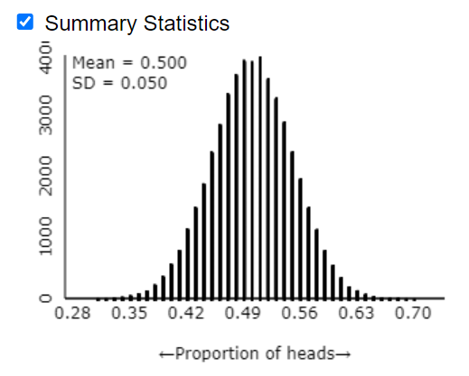

\(\text{probability of success}(\pi) = 0.50\)  
\(\text{sample size}(n) = 100\)

Simulate the sampling distribution using the ISI [One-Proportion](http://www.isi-stats.com/isi2nd/ISIapplets2021.html) applet. Notice that the curve shape is *slightly* right skewed this time. What key CLT idea might not be not met in this example?

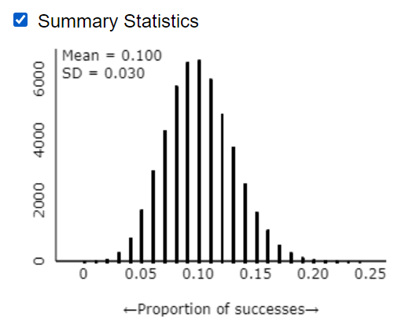

\(\text{probability of success}(\pi) = 0.10\)  
\(\text{sample size}(n) = 100\)

## Increasing \(n\), Same \(\pi\)—Notice \(SD(\hat{p})\)

| \(n\) | \(\text{Mean}(\hat{p}) = \pi\) | \(SD(\hat{p})\) |
| --- | --- | --- |
| 25 | 0.50 | 0.1000 |
| 50 | 0.50 | 0.0707 |
| 100 | 0.50 | 0.0500 |
| 200 | 0.50 | 0.0354 |
| 400 | 0.50 | 0.0250 |
| 800 | 0.50 | 0.0177 |

Observe that \(SD(\hat{p})\) gets progressively smaller as \(n\) gets larger. If we quadruple \(n\), then \(SD(\hat{p})\) gets cut in half.

## Visualize \(SD(\hat{p})\) for Changing \(n\)

[figure not shown]

## Same \(n\), Different \(\pi\)—Notice \(SD(\hat{p})\)

| \(n\) | \(\text{Mean}(\hat{p}) = \pi\) | \(SD(\hat{p})\) |
| --- | --- | --- |
| 100 | 0.10 | 0.0300 |
| 100 | 0.25 | 0.0433 |
| 100 | 0.50 | 0.0500 |
| 100 | 0.75 | 0.0433 |
| 100 | 0.90 | 0.0300 |

Observe that \(SD(\hat{p})\) is largest when \(\pi = 0.50\) and gets smaller as \(\pi\) gets closer to either \(0\) or \(1\). We will revisit this idea when we get to confidence interval estimation in Chapter 3.

## Visualize \(SD(\hat{p})\) for Changing \(\pi\)

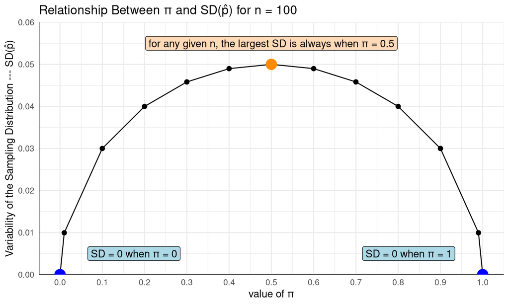

## Why “Central”?

The term *central* in the name Central Limit Theorem refers to its overall importance; it is **central** to much of statistical theory and methods. Mathematician George Polya is credited with inventing the name (though not the idea) in a 1920 paper.

The Central Limit Theorem applies to sample means when \(n\) is large enough. The sampling distribution of the sample mean \(\bar{x}\) :

- will be will be approximately normal
- will have a mean equal to the population mean \(\mu\)
- will have \(SD(\bar{x})\) equal to the population standard deviation \(\sigma\) over the square root of the sample size, \(\sigma / \sqrt{n}\)

## Type of Sampling Matters!

- Statistical methods are designed to handle *random sampling variability* in our data.
- If the sample we have is biased, we have to be careful about *generalizing* to the population the sample came from.
- Population size does not affect sampling variability as long as the population is at least \(20\) times the size of the sample.
- A larger sample size is not helpful if the sampling method is biased. You essentially just get a larger amount of *bad* data (as well as a false sense of confidence in your findings).
- Bias can get into our data in from both the sampling method (e.g., using convenience samples) and nonsampling sources (e.g., writing bad survey questions).

## Imagination & Simulation!

[figure not shown]

Image from [*Applied Biostatistics*](https://bookdown.org/kmbm92/Applied-Biostats/) by Pleuni Pennings and Kevin Magnaye